# A Framework to Estimate Waterbirds Population Trends by Multi Datasources

A.Y. Chang

10 Aug. 2018

## Introduction

To make the decisions on biodiversity conservation, it is necessary to evaluate the population trends of target species. For the migratory waterbirds of the East Asian-Australasian Flyway (EAAF), Taiwan is one of the most important stopover sites and wintering sites for them and the Taiwanese birders have accumulated a huge volume of data. However, the distribution data of migratory waterbirds have not been integrated and analyzed effectively, especially for the long-term population trends. Therefore, this study aims at (1) harmonize the data from different sources and (2) identify the population trends of the target species.

## Data Collection

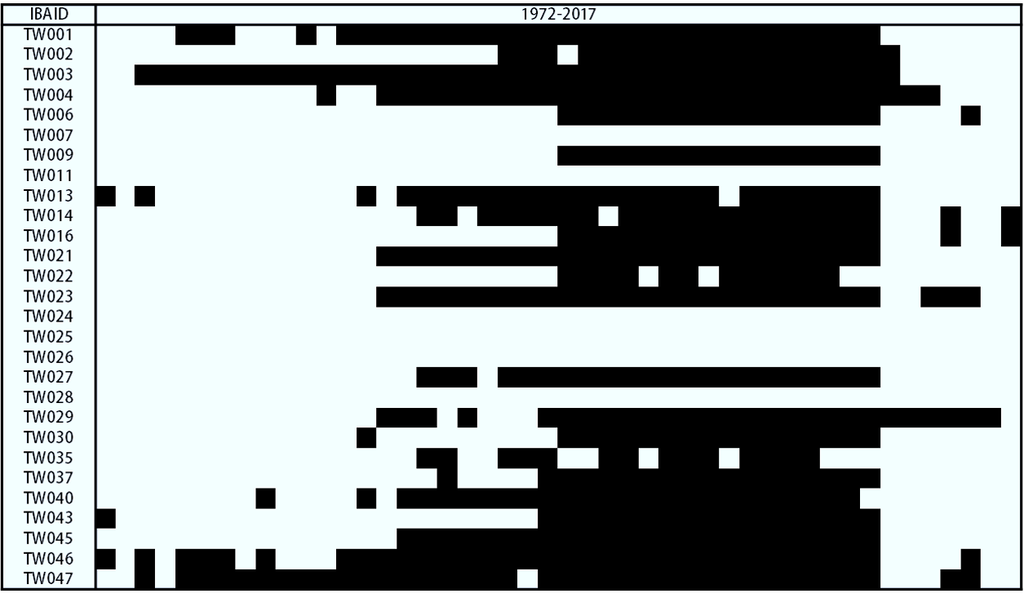

Black = count data available, white = no count data that year.

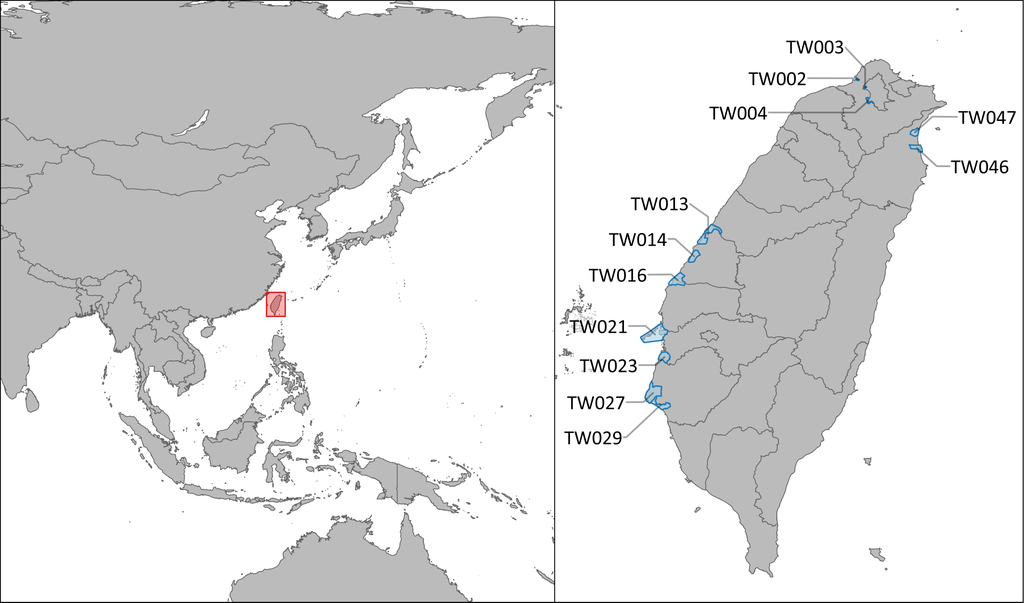

**Figure2.** Location of study sites: 12 wetland Important Bird Areas in Taiwan

| IBA ID | Name | IBA ID | Name |
| --- | --- | --- | --- |
| TW002 | Guandu | TW003 | Waziwei |
| TW004 | Huajiang | TW013 | Hanbao Wetland |
| TW014 | Fangyuan Wetland | TW016 | Zhuoshui River Estuary Wetland |
| TW021 | Aogu Wetland | TW023 | Budai Wetland |
| TW027 | Qigu | TW029 | Sicao |
| TW046 | Lanyang River Estuary | TW047 | Zhu’an |

We harmonized 26 open datasets, which includes 1 citizen science project (New Year Bird Count Taiwan, NYBC), 2 birding checklists databases (eBird and Chinese Wild Bird Federation (CWBF) database) and other 23 monitoring projects, of these 12 wetland IBAs. Before integrated all datasets into one ready dataset, we did some basic data manipulation, such as removing records without coordinates of survey site and timeing of survey, matching species in each dataset to the same bird list, extract essential information (columns) needed.  
The ready dataset contains 17,018 complete checklists, including 126 waterbird species from 1972 to 2017.

Here’s the structure of the final dataset.

sci.name = Scientific name, type = Type of projects, source = ID of projects, obs.count = Observation count, Year = Record year, Month = Record month, IBA = ID of Important Bird Area, county = County ID, f_id = Event ID of checklist

| sci.name | type | source | obs.count | Year | Month | IBA | county | f_id |
| --- | --- | --- | --- | --- | --- | --- | --- | --- |
| Tadorna tadorna | M&C | M&C_1 | 2 | 2005 | 1 | TW029 | TNC | 2006_01_保護區東區 |
| Tadorna tadorna | M&C | M&C_1 | 1 | 2005 | 2 | TW029 | TNC | 2006_02_保護區東區 |
| Anas penelope | M&C | M&C_1 | 14 | 2003 | 11 | TW029 | TNC | 2003_11_工業區東區 |
| Anas penelope | M&C | M&C_1 | 124 | 2003 | 11 | TW029 | TNC | 2003_11_工業區西區 |
| Anas penelope | M&C | M&C_1 | 24 | 2003 | 11 | TW029 | TNC | 2003_11_東區外圍17省 |
| Anas penelope | M&C | M&C_1 | 23 | 2003 | 11 | TW029 | TNC | 2003_11_保護區東區 |

## Characteristics of the ready dataset

Before going to analysis, We did some data exploration to the ready dataset.

#### 1. Number of checklists in ready dataset along year

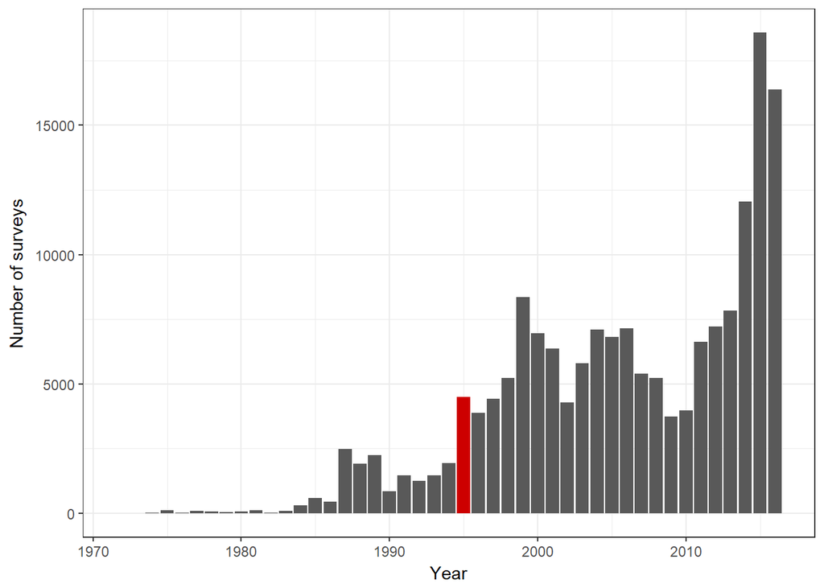

```r
data.01 <- bird.final %>%
  .[, .(`Number of surveys` = .N), by = Year]
ggplot() +
  geom_col(data = data.01,
           aes(x = Year, y = `Number of surveys`)) +
  geom_col(data = data.01[Year == 1995],
           aes(x = Year, y = `Number of surveys`),
           fill = "red3") +
  theme_bw()
```

In the ready dataset, the number of complete checklists sharply increased in 1995.

#### 2. Number of ckecklists in each IBA along year

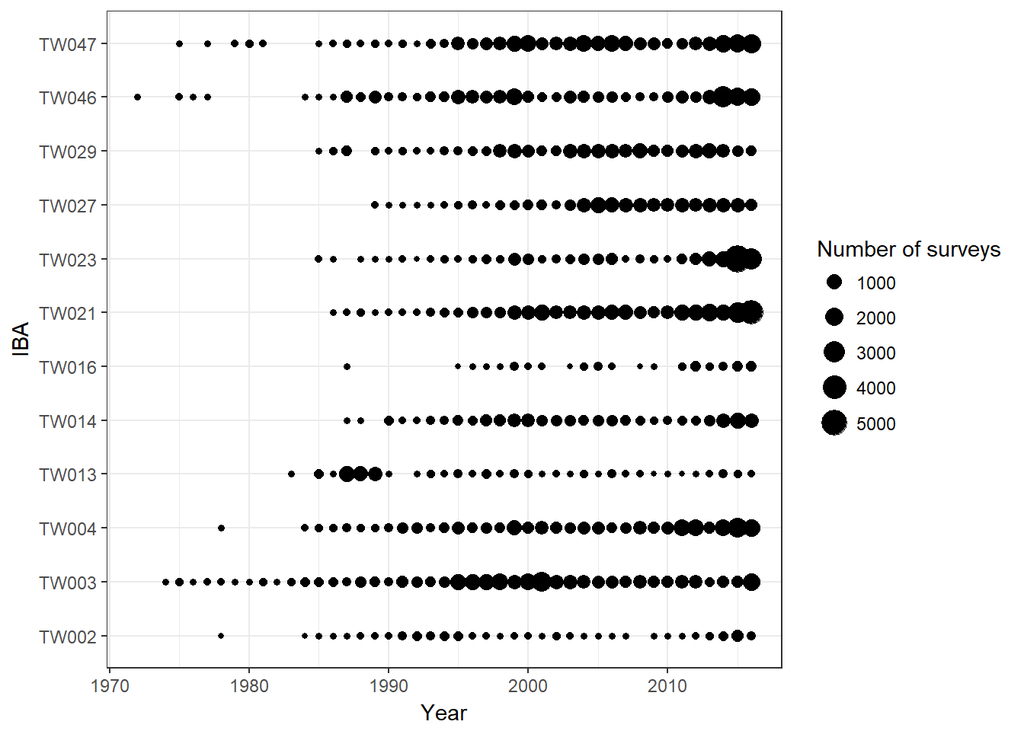

```r
data.02 <- bird.final %>%
  .[, .(`Number of surveys` = .N), by = list(Year, IBA)]
ggplot() +
  geom_point(data = data.02,
             aes(x = Year, y = IBA, size = `Number of surveys`)) +
  theme_bw()
```

All IBAs seems with sufficent checklists. So we includes all the 12 IBAs as our study sites.

#### 3. Number of checklists of different source types

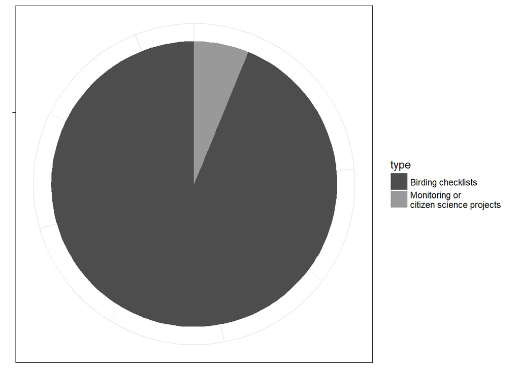

```r
data.03 <- bird.final %>%
    .[, .(N = uniqueN(f_id)),
          by = type]

ggplot(data = data.03,
       aes(x = "", y = N, fill = type)) +
  geom_bar(width = 1, stat  = "identity") +
  coord_polar("y", start = 0) +
  scale_fill_manual(labels = c("Birding checklists",
                               "Monitoring or \ncitizen science projects"),
                    values = c("grey30", "grey60")) +
  theme_bw() +
  theme(axis.title = element_blank(),
        axis.text = element_blank())
```

As the figure showed above, most data in the ready dataset are composed of birding checklists (93.8%).

It is difficult to count the actual number of waterbirds in the field. Even monitoring data recorded by specific investigators will have some bias, not to mention that the birding checklist came from numbers of birders. Therefore, the noise of ready dataset is not only from the birders’ personal detectability, but also produced by integrating different sources of datasets with variate survey efforts.

## Subset data for population trend analysis

Based on the result of data explration above, we set some criteria to subset the ready dataset for trend analysis:

1. To avoid the bias due to unsufficient sample size of checklists, we conducted the trend analysis from 1995 to 2017.
2. To find the signals of noise dataset, for each species, we extract the annual maximum count per IBA of each dataset.

Owing to the pourpose of this analysis is to estimate the population trends, we set two more criterias here:

3. Only includes records of IBA if there are more than 5 years of records (per species)
4. Select IBAs with main population of Taiwan (per species)

#### 1. Extract annual maximum count per IBA of each species

```r
data.S1 <-
  bird.final[, .(max.count = max(obs.count, na.rm = T)),
            by = list(sci.name, Year, IBA, source)] %>%
  .[max.count != 0]
```

#### 2. Remove records before 1995

```r
data.S2 <-
  data.S1[Year > 1994]
```

#### 3. Only includes records of IBA if there are more than 5 years of records (per species)

```r
# table for number of years of record per IBA
N.year.IBA <-
  data.S2[, .(N = .N,
              nYear = uniqueN(Year)),
          by = list(sci.name, IBA)]
# filter by nYear > 5
data.S3  <-
  lapply(unique(data.S2[, sci.name]),
         function(x){
           IBA.list <- N.year.IBA[sci.name == x & nYear > 5, IBA]
           data <- data.S2[sci.name == x &
                             IBA %in% IBA.list]
           return(data)
         }
  ) %>%
  do.call(rbind, .)
```

#### 4. Select IBA with main population of Taiwan (per species)

What we concernd is the overall population trends of Taiwan. According to our experience in the field, there is a big difference between population size of each species in IBAs. So we set the criteria to pick the IBAs with main population only of each target species, and use the records of these IBAs only for trend analysis. For each species, we use mean of annual maximum count from 1995 to 2017 as an index of population size of an IBA. And use 20% of the maximum population size as a threshold. If population size of an IBA exceed the threshold, it will be keep in the dataset for trend analysis.

```r
# calculate population size of each IBA per species
table.IBA <-
  data.S3[, .(mean = mean(max.count)),
          by = list(IBA, sci.name)] %>%
  .[, mmean := max(mean)/5, by = sci.name]
# select IBA by threshold per species
data.S4 <-
  lapply(unique(data.S3$sci.name),
         function(x)
           data.S3[sci.name == x &
                     IBA %in% table.IBA[sci.name == x &
                                          mean > mmean, IBA]]
  ) %>%
  do.call(rbind, .)
```

## Trend analysis

List of 11 target species:

Common Teal (Anascrecca),Little Egret (Egrettagarzetta), Black-faced Spoonbill (Plataleaminor), Pacific Golden Plover (Pluvialisfulva), Kentish Plover (Charadriusalexandrinus), Eurasian Curlew (Numeniusarquata), Ruddy Turnstone (Arenariainterpres), Red-necked Stint (Calidrisruficollis), Dunlin (C. alpina), Black-headed Gull (Chroicocephalusridibundus) and Saunders’s Gull (Saundersilarussaundersi).

```r
# use mean annual maximum count of IBA to weight trend
data.w <- data.S4 %>%
  .[, pop := mean(max.count), by = list(IBA, sci.name)] %>%
  # rescale year
  .[, Year.s := Year - mean(unique(Year))]


# list of target species
sci_name <- c(
  'Egretta garzetta',
  'Anas crecca',
  'Charadrius alexandrinus',
  'Calidris alpina',
  'Pluvialis fulva',
  'Platalea minor',
  'Chroicocephalus ridibundus',
  'Calidris ruficollis',
  'Numenius arquata',
  'Arenaria interpres',
  'Saundersilarus saundersi'
)

#------ model construction for each species
# to reduce the time waiting for the results, we use paralle processing here

# setting for paralle processing
cl <- makeCluster(7)
clusterExport(cl, c("sci_name", "data.w"))
clusterEvalQ(cl, c(library(glmmTMB),
                   library(data.table))) %>%
  invisible()

# model building for each species
system.time(
  nb.W <-
    parLapply(cl, 1:length(sci_name), function(x)
      tryCatch({
        glmmTMB(count ~ Year.s + (0 + Year.s|IBA) + (1|IBA),
                ziformula = ~0,
                weight = pop,
                data = data.w[sci.name == sci_name[x]],
                family = nbinom2)
      },
      error = function(e)
      {cat("ERROR :",conditionMessage(e), "\n")})
    )
)

# stop paralle processing
stopCluster(cl)

# save model as .RData
save(nb.W, file = file.path(ResultDir, "nbmodle_weight.RData"))

#-- export results as data.frame
result.table <-
  lapply(1:length(sci_name), function(x)
    data.table(Estimate = coef(summary(nb.W[[x]]))$cond[2, 1],
               Std.Error = coef(summary(nb.W[[x]]))$cond[2, 2],
               z.value = coef(summary(nb.W[[x]]))$cond[2, 3],
               P.value = coef(summary(nb.W[[x]]))$cond[2, 4],
               sci.name = sci_name[x])) %>%
  do.call(rbind, .)
```

## Results

The population trend of seven waterbirds (Common Teal, Little Egret, Kentish Plover, Eurasian Curlew, Dunlin, Saunders’s Gull, Black-headed Gull) decreased significantly, and which of the other four species were no significances.

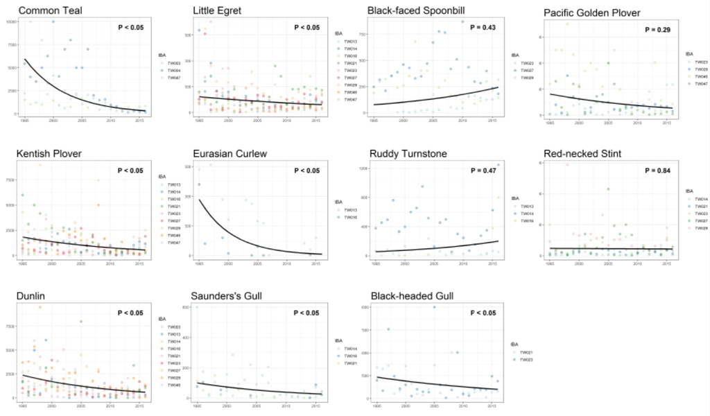

## Discussions

#### Building framework in R

In this study, we constructed a framework to approach the population trends of waterbirds from different open datasets. This framework includes the progress of data collection and building model to estimate population trend. We build all the proccess in R, which make it has high repeatability and easy to modify. This framework should be a standard procedure for evaluating population trend, especially for the datasets from different sources and efforts.

#### Find signal in noise

It is difficult to count the actual number of waterbirds in the field. Therefore, the noise of ready dataset is not only from the birders’ personal detectability, but also produced by integrating different sources of datasets with variate survey efforts. To find the signals of noise dataset, we use the annual maximum count of each target species in each dataset only for trend analysis.

#### Compare the trends of Taiwan with that of global

We compared the population trends of Taiwan with that of global from 1977 to 2012 (BirdLife, 2018). Generally, most results of Taiwan are consistent with that of global. Exclude 2 species with unknown global trend, 7 species show similar trend to global trend.

[output not shown]

## References

A., Magnusson et al. (2017). (available at https://CRAN.R-project.org/package=glmmTMB)  
BirdLife International, Species factsheet (available at http://www.birdlife.org)  
Chinese Wild Bird Federation database. (available at http://webdata.bird.org.tw/)  
eBird Basic Dataset. Version: EBD_relMay-2017. Cornell Lab of Ornithology, Ithaca, New York. (2017).  
J., Walker and P. D. Taylor. Avian Conservation and Ecology 12, 4 (2017).  
New Year Bird Count Taiwan. (available at http://nybc.bird.org.tw/)  
R., Clemens et al. Emu – Austral Ornithology 116,119-135 (2016).  
R., Clemens et al. Stilt, 62, 3-17. (2012).  
T. Amano et al., Biological Conservation 143, 2238-2247 (2010).

If you are intresting to the part of visualization, here’s the compelete code.

```r
#------ data for geom_line()
# trend from 1995 to 2016
YY <- 1995:2016 - mean(unique(data.w$Year))
pred.table <-
  lapply(1:length(sci_name), function(x){
    g <- fixef(nb.W[[x]])[[1]][1] + fixef(nb.W[[x]])[[1]][2]*YY
    h <- exp(g)
    pred.table <- data.table(sci.name = sci_name[x],
                             Year = 1995:2016,
                             predicted = h)
    return(pred.table)
  }) %>%
  do.call(rbind, .)

#------ estimated trend (plot)
lapply(1:length(sci_name), function(x){
  grob <- grobTree(textGrob(result.table[x,6],
                            x = 0.75, y = 0.9, hjust = 0),
                   gp = gpar(fontsize = 16, fontface = "bold"))
  # data for geom_point()
  point.data <-
    data.w[sci.name == sci_name[x],
            .(count = mean(count)),
            by = list(Year, IBA)]
  trend.plot <- ggplot() +
    geom_point(data = point.data,
               aes(x = Year, y = count, color = IBA),
               stroke = 1.2, size = 1.2, alpha = .6, shape = 21) +
    scale_colour_brewer("IBA", palette="Paired") +
    geom_line(data = pred.table[sci.name == sci_name[x]],
              aes(x = Year, y = predicted), size = 1.2) +
    labs(title = common_name[x], x = NULL, y = NULL) +
    annotation_custom(grob) +
    theme_bw() +
    theme(plot.title = element_text(size=24))
  ggsave(paste0("model_", common_name[x], "_weight_IBA2.png"),
         plot = trend.plot,
         path = ResultDir,
         width = 6, height = 4, dpi = 300)
}) %>%
  invisible()
```